# Sparkify Small Dataset EDA and Feature Engineering

This notebook is dedicated to the following tasks:

cleaning and preprocessing small dataset,

feature engineering on the small dataset,

EDA on the processed data,

stratified split of the data into training and test sets

feature relevance and feature selection considerations.

## Set Environment

```python
# import PySpark libraries and packages

import pyspark
from pyspark import SparkContext
from pyspark import SparkConf

from pyspark.sql import SparkSession
from pyspark.sql.window import Window as W

from pyspark.sql.types import (
    StringType,
    IntegerType,
    DateType,
    TimestampType,
    )

from pyspark.sql.functions import (
    min as Fmin, max as Fmax,
    sum as Fsum, round as Fround,

    col, lit,
    first, last,
    desc, asc,
    avg, count, countDistinct,
    when, isnull, isnan,
    from_unixtime,
    datediff,
    )
```

```python
# build a Spark session using the SparkSession APIs

spark = (SparkSession
        .builder
        .appName("Sparkify")
        .getOrCreate())

spark.sparkContext.setLogLevel("WARN")
```

```python
# import python libraries

import numpy as np
import pandas as pd
import matplotlib.pyplot as plt
```

```python
# import library for enhanced plotting

import seaborn as sns
sns.set_style("darkgrid")
colors = sns.color_palette('PuBuGn_r')
```

## Load and Clean Dataset

```python
def load_data(file_path):
    """
    Loads the raw dataset in Spark.

    INPUT:
            (str) - path for datafile
    OUTPUT:
            (PySpark dataframe) - dataframe of raw data

    """

    print("Loading the dataset ...")
    df = spark.read.json(file_path)
    print("Dataset is loaded...")

    return df
```

```python
def clean_data(df):
    """
    Performs basic cleaning operations on the raw data:
        - removes entries with missing userId
        - rescale timestamp columns to seconds
        - drop unnecesary columns
            - personal information columns
            - song information columns
            - web and browser information
            - timestamp columns in miliseconds

    INPUT:
            (PySpark dataframe) - dataframe of raw data
    OUTPUT:
            (PySpark dataframe) - dataframe of cleaned data
    """

    # print message to indicate the start of the process
    print("Cleaning the data ...")

    # print a count of rows before cleaning
    initial_records = df.count()
    print("Dataset has {} rows initially.".format(initial_records))

    # filter out all the records without userId
    df = df.where(df.userId != "")

    # rescale the timestamp to seconds (initially in miliseconds)
    df = df.withColumn("log_ts", df.ts/1000.0)
    df = df.withColumn("reg_ts", df.registration/1000.0)

    # drop several columns
    cols_to_drop = ("firstName", "lastName", "location",
                    "artist", "song", "length",
                    "userAgent", "method", "status",
                    "ts", "registration"
                   )
    df = df.drop(*cols_to_drop)


    # print end of process message
    print("Finished cleaning the data ...")

    # print a count of rows after cleaning
    removed_rows = initial_records - df.count()

    print("Cleaned dataset has {} rows, {} rows were removed". \
        format(df.count(), initial_records - df.count()))

    return df
```

```python
def save_data(df, data_path):
    """
    Saves the PySpark dataframe to a file.

    INPUT:
            df (PySpark dataframe) - data to be saved
            data_path (str) - path for datafile
    OUTPUT:
            none

    """

    df.write.json(data_path)
```

```python
# create a path variable for the small dataset file
mini_path = "data/mini_sparkify_event_data.json"
# read the mini dataset
mini_sparkify = load_data(mini_path)
# clean the mini dataset
df = clean_data(mini_sparkify)
```

```
Loading the dataset ...
```

```
Dataset is loaded...
Cleaning the data ...
Dataset has 286500 rows initially.
Finished cleaning the data ...
Cleaned dataset has 278154 rows, 8346 rows were removed
```

```python
# path for the cleaned data
#clean_data_path = "data/mini_sparkify_clean_data.json"

# save the cleaned data to a file
#save_data(df, clean_data_path)

# upload the clean data
#df = load_data(clean_data_path)
```

```python
# check the structure of the data after cleaning
df.printSchema()
```

```
root
 |-- auth: string (nullable = true)
 |-- gender: string (nullable = true)
 |-- itemInSession: long (nullable = true)
 |-- level: string (nullable = true)
 |-- page: string (nullable = true)
 |-- sessionId: long (nullable = true)
 |-- userId: string (nullable = true)
 |-- log_ts: double (nullable = true)
 |-- reg_ts: double (nullable = true)
```

```python
# take a look at the cleaned data
df.show(1, vertical=True)
```

```
-RECORD 0----------------------
 auth          | Logged In
 gender        | M
 itemInSession | 50
 level         | paid
 page          | NextSong
 sessionId     | 29
 userId        | 30
 log_ts        | 1.538352117E9
 reg_ts        | 1.538173362E9
only showing top 1 row
```

### Toggle the memory

```python
# save to storage level 'MEMORY'
df_cached = df.cache()
```

## Preprocess Dataset

```python
def preprocess_data(df):

    """
    Prepare the data for modeling via creating several features.

     - reg_date (date) - month-year of the registration

     - create windows grouped on userId and sessionId

     - firstevent_ts (timestamp) - first time an user is active
     - lastevent_ts (timestamp) - last time an user is active

     - init_days_interv (float) - days between registration and first activity
     - tenure_days_interv (float) - days between registration and last activity
     - active_days (float) - days the user has some activity on the platform
     - session_h (float) - session's duration in hours

     INPUT:
         df (PySpark dataframe) - cleaned dataframe
     OUTPUT:
         df (PySpark dataframe) - dataframe with the listed features added
    """

    # extract registration month and year from timestamp
    df = df.withColumn("reg_date", from_unixtime(col("reg_ts"), "MM-yyyy"))

    # create window: data grouped by userId, time ordered
    win_user = (W.partitionBy("userId")
            .orderBy("log_ts")
            .rangeBetween(W.unboundedPreceding, W.unboundedFollowing))

    # create window: data grouped by sessionId and userId, time ordered
    win_user_session = (W.partitionBy("sessionId", "userId")
                    .orderBy("log_ts")
                    .rangeBetween(W.unboundedPreceding, W.unboundedFollowing))


    # record the first time an user is active
    df = df.withColumn("firstevent_ts", first(col("log_ts")).over(win_user))
    # record the last time an user is active
    df = df.withColumn("lastevent_ts", last(col("log_ts")).over(win_user))


    # warmup time = registration time to first event in days
    df = df.withColumn("init_days_interv",
                       (col("firstevent_ts").cast("long")-col("reg_ts").cast("long"))/(24*3600))

    # tenure time = registration time to last event in days
    df = df.withColumn("tenure_days_interv",
                       (col("lastevent_ts").cast("long")-col("reg_ts").cast("long"))/(24*3600))

    # active time =  days between the first event and the last event in days
    df = df.withColumn("active_days",
                       (col("lastevent_ts").cast("long")-col("firstevent_ts").cast("long"))/(24*3600))

    # create column that records the individual session's duration in hours
    df = df.withColumn("session_h",
                    (last(df.log_ts).over(win_user_session) \
                     - first(df.log_ts).over(win_user_session))/3600)

    # drop columns
    df = df.drop("reg_ts", "log_ts")

    return df
```

```python
# preprocess mini dataset
df_proc = preprocess_data(df_cached)
```

```python
# display the features in the preprocessed dataframe
df_proc.printSchema()
```

```
root
 |-- auth: string (nullable = true)
 |-- gender: string (nullable = true)
 |-- itemInSession: long (nullable = true)
 |-- level: string (nullable = true)
 |-- page: string (nullable = true)
 |-- sessionId: long (nullable = true)
 |-- userId: string (nullable = true)
 |-- reg_date: string (nullable = true)
 |-- firstevent_ts: double (nullable = true)
 |-- lastevent_ts: double (nullable = true)
 |-- init_days_interv: double (nullable = true)
 |-- tenure_days_interv: double (nullable = true)
 |-- active_days: double (nullable = true)
 |-- session_h: double (nullable = true)
```

```python
# take a look at the pre-processed data
df_proc.show(1, vertical=True)
```

```
[Stage 10:====>                                                   (1 + 11) / 12]
```

```
-RECORD 0---------------------------------
 auth               | Logged In
 gender             | M
 itemInSession      | 0
 level              | free
 page               | NextSong
 sessionId          | 2
 userId             | 200002
 reg_date           | 09-2018
 firstevent_ts      | 1.53839343E9
 lastevent_ts       | 1.542324354E9
 init_days_interv   | 24.577824074074073
 tenure_days_interv | 70.07462962962963
 active_days        | 45.496805555555554
 session_h          | 0.20166666666666666
only showing top 1 row
```

```python
# path for the pre-processed data
#processed_data_path = "data/mini_sparkify_processed_data.json"

# save the pre-processed data to a file
#save_data(df_proc, processed_data_path)
```

## Feature Engineering

In this section:

several new features are created,

a new PySpark dataframe with one row per user is created,

the target feature denoted "churn" is created from "Cancellation Confirmation" page.

```python
def build_features(df):

    """
    Features engineered to be used in modelling.

    - nr_songs (int) - total number of songs user listened to
    - nr_playlist (int) - number of songs added to the playlist

    - nr_friends (int) - number of friends added through "Add Friend"

    - nr_likes (int) - total number of "Thumbs Up" of the user
    - nr_dislikes (int) - total number of "Thumbs Down" of the user

    - nr_downgrades (int) - total number of visits to "Downgrade" page by the user
    - nr_upgrades (int) - total number of visits to "Upgrade" page by the user

    - nr_home (int) - total number of visits to "Home" page by the user
    - nr_settings (int) - total number of visits to "Settings" page by the user

    - nr_error (int) - total number of errors encountered by the user

    - nr_ads (int) - total number of ads the user got
    - nr_sessions (int) - number of sessions of the user
    - n_acts (int) - total number of actions taken by the user

    - avg_sess_h (float) - average session length in hours
    - acts_per_session (float) - average number of actions per session for the user
    - songs_per_session (float) - average numer of songs listened per session by the user
    - ads_per_session (float) - average number of ads per session, received by user

    - init_days_interv (int) - time interval in days from registration to the first action of the user
    - tenure_days_interv (int) - time interval in days from registration to the last action of the user
    - active_days (int) - number of days the user was active on the platform

    - gender (binary) - 1 for F (female), 0 for M (male)
    - level (binary) - 1 for paid, 0 for free

    - churn (binary) - 1 for "Cancellation Confirmation" page visit, 0 otherwise

    INPUT:
        df (PySpark dataframe) - preprocessed dataframe
        df_feats (PySpark datafrane) - dataframe that contains engineered features
    """

    df_feats = df.groupBy("userId") \
        .agg(

            # count user's individual actions using all page visits

            count(when(col("page") == "NextSong", True)).alias("nr_songs"),
            count(when(col("page") == "Add to Playlist", True)).alias("nr_playlist"),

            count(when(col("page") == "Add Friend", True)).alias("nr_friends"),

            count(when(col("page") == "Thumbs Up", True)).alias("nr_likes"),
            count(when(col("page") == "Thumbs Down", True)).alias("nr_dislikes"),

            count(when(col("page") == "Downgrade", True)).alias("nr_downgrades"),
            count(when(col("page") == "Upgrade", True)).alias("nr_upgrades"),

            count(when(col("page") == "Home", True)).alias("nr_home"),
            count(when(col("page") == "Settings", True)).alias("nr_settings"),

            count(when(col("page") == "Error", True)).alias("nr_error"),

            count(when(col("page") == "Roll Advert", True)).alias("nr_ads"),

            # compute the number of sessions a user is in
            countDistinct("sessionId").alias("nr_sessions"),

            # find the total number of actions a user took
            countDistinct("itemInSession").alias("n_acts"),

            # compute the average session length in hours
            avg(col("session_h")).alias("avg_sess_h"),

            # compute the average number of page actions per sesssion - i.e. items in session
            (countDistinct("itemInSession")/countDistinct("sessionId")).alias("acts_per_session"),

            # compute the average number of songs per session
            (count(when(col("page") == "NextSong",
                        True))/countDistinct("sessionId")).alias("songs_per_session"),

            # compute the average number of ads per session
             (count(when(col("page") == "Roll Advert",
                         True))/countDistinct("sessionId")).alias("ads_per_session"),

            # days between registration and first activity
            first(col("init_days_interv")).alias("init_days_interv"),
            # the tenure time on the platform: from registration to last event in days
            first(col("tenure_days_interv")).alias("tenure_days_interv"),
            # number of days user visited the platform, is active on the platform
            first(col("active_days")).alias("active_days"),

            # encode the gender 1 for F and 0 for M
            first(when(col("gender") == "F", 1).otherwise(0)).alias("gender"),

            # encode the level (paid/free) according to the last record
            last(when(col("level") == "paid", 1).otherwise(0)).alias("level"),

            # flag those users that downgraded
            #last(when(col("page") == "Downgrade", 1).otherwise(0)).alias("downgrade"),

            # create the churn column that records if the user cancelled
            last(when(col("page") == "Cancellation Confirmation", 1).otherwise(0)).alias("churn"),
            )

    # drop columns, some based on feature selection outcome
    df_feats = df_feats.drop("userId")

    # drop the null values
    df_feats=df_feats.na.drop()

    return df_feats
```

```python
# build the features dataframe for mini dataset
df_feats = build_features(df_proc)

# check the output dataframe
df_feats.printSchema()
```

```
root
 |-- nr_songs: long (nullable = false)
 |-- nr_playlist: long (nullable = false)
 |-- nr_friends: long (nullable = false)
 |-- nr_likes: long (nullable = false)
 |-- nr_dislikes: long (nullable = false)
 |-- nr_downgrades: long (nullable = false)
 |-- nr_upgrades: long (nullable = false)
 |-- nr_home: long (nullable = false)
 |-- nr_settings: long (nullable = false)
 |-- nr_error: long (nullable = false)
 |-- nr_ads: long (nullable = false)
 |-- nr_sessions: long (nullable = false)
 |-- n_acts: long (nullable = false)
 |-- avg_sess_h: double (nullable = true)
 |-- acts_per_session: double (nullable = true)
 |-- songs_per_session: double (nullable = true)
 |-- ads_per_session: double (nullable = true)
 |-- init_days_interv: double (nullable = true)
 |-- tenure_days_interv: double (nullable = true)
 |-- active_days: double (nullable = true)
 |-- gender: integer (nullable = true)
 |-- level: integer (nullable = true)
 |-- churn: integer (nullable = true)
```

```python
# path for the features data
#features_data_path = "data/mini_sparkify_features_data.json"

# save the features data to a file
#save_data(df_feats, features_data_path)
```

### Toggle the memory

```python
# unpersist the dataframe df
df_cached.unpersist()
```

```
DataFrame[auth: string, gender: string, itemInSession: bigint, level: string, page: string, sessionId: bigint, userId: string, log_ts: double, reg_ts: double]
```

```python
# save the featured PySpark dataframe to memory
df_feats_cached = df_feats.cache()
```

```
22/01/19 21:28:21 WARN package: Truncated the string representation of a plan since it was too large. This behavior can be adjusted by setting 'spark.sql.debug.maxToStringFields'.
```

### Investigate missing and null values

```python
# count null and nan values in each column
df_feats_cached.select([count(when(isnan(c) | col(c).isNull(), c)) \
           .alias(c) for c in df_feats_cached.columns]) \
           .show(vertical=True)
```

```
[Stage 14:==================================================>  (189 + 11) / 200]
```

```
-RECORD 0-----------------
 nr_songs           | 0
 nr_playlist        | 0
 nr_friends         | 0
 nr_likes           | 0
 nr_dislikes        | 0
 nr_downgrades      | 0
 nr_upgrades        | 0
 nr_home            | 0
 nr_settings        | 0
 nr_error           | 0
 nr_ads             | 0
 nr_sessions        | 0
 n_acts             | 0
 avg_sess_h         | 0
 acts_per_session   | 0
 songs_per_session  | 0
 ads_per_session    | 0
 init_days_interv   | 0
 tenure_days_interv | 0
 active_days        | 0
 gender             | 0
 level              | 0
 churn              | 0
```

## Exploratory Data Analysis on Engineered Features

```python
# for visualizations we read PySpark dataframe into Pandas
df_panda = df_feats_cached.toPandas()
```

### Distribution of Churn

```python
# the distribution of churn

churn_counts = df_feats_cached.groupBy("churn").count()
churn_counts.show()
```

```
+-----+-----+
|churn|count|
+-----+-----+
|    1|   52|
|    0|  173|
+-----+-----+
```

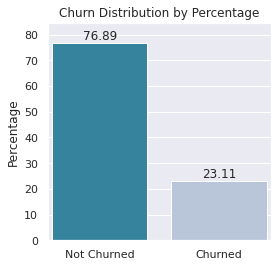

```python
# adjust figure size and font size
sns.set(rc = {"figure.figsize":(4,4)})
sns.set(font_scale=1)

# plot the churn distribution
ax = sns.barplot(x='churn', y='churn', data=df_panda,
                 estimator=lambda x: len(x) / len(df_panda) * 100,
                 palette='PuBuGn_r')

# pad margins so that markers don't get clipped by the axes
plt.margins(x=0.02, y=0.1, tight=True);

# create labels and ticks
for container in ax.containers:
    ax.bar_label(container, fmt='%.2f')
ax.set(xticklabels =["Not Churned", "Churned"])
ax.set(xlabel="")
ax.set(ylabel="Percentage")

# create title
plt.title("Churn Distribution by Percentage");
```

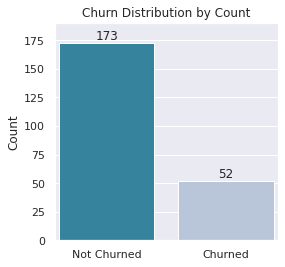

```python
# adjust figure size and font size
sns.set(rc = {"figure.figsize":(4,4)})
sns.set(font_scale=1)

# plot the churn distribution
ax = sns.countplot(x='churn', data=df_panda,
                palette='PuBuGn_r')

# pad margins so that markers don't get clipped by the axes
plt.margins(x=0.02, y=0.1, tight=True);

# create labels and ticks
for container in ax.containers:
    ax.bar_label(container)

ax.set(xticklabels =["Not Churned", "Churned"])
ax.set(xlabel="")
ax.set(ylabel="Count")

# create title
plt.title("Churn Distribution by Count");
```

```python
# compute the churn rate via: churned/all users
churn_rate = round(df_feats.where(df_feats.churn==1).count() / df_feats.count(), 4)

print("The churned rate is {} %.".format(churn_rate * 100))
```

```
The churned rate is 23.11 %.
```

### Distribution of Churn on Gender

```python
# counts of churn/non_churn users grouped by gender
df_feats_cached.crosstab("churn", "gender").sort("churn_gender").show()
```

```
+------------+---+---+
|churn_gender|  0|  1|
+------------+---+---+
|           0| 89| 84|
|           1| 32| 20|
+------------+---+---+
```

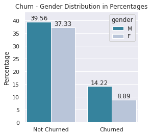

```python
# adjust figure size and font size
sns.set(rc = {"figure.figsize":(4,4)})
sns.set(font_scale=1)

# plot the churn distribution
ax = sns.barplot(x='churn', y='churn', data=df_panda,
                 estimator=lambda x: len(x) / len(df_panda) * 100, hue='gender',
                 palette='PuBuGn_r')

# pad margins so that markers don't get clipped by the axes
plt.margins(x=0.02, y=0.1, tight=True);

# create labels and ticks
for container in ax.containers:
    ax.bar_label(container, fmt='%.2f')

ax.set(xticklabels =["Not Churned", "Churned"])
ax.set(xlabel="")
ax.set(ylabel="Percentage")

# restyle legend
labels = ['M', 'F']
h, l = ax.get_legend_handles_labels()
ax.legend(h, labels, title="gender")

# create title
plt.title("Churn - Gender Distribution in Percentages");
```

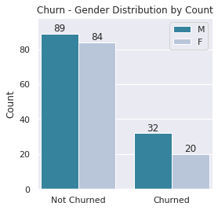

```python
# adjust figure size and font size
sns.set(rc = {"figure.figsize":(4,4)})
sns.set(font_scale=1)

# plot the churn distribution
ax3 = sns.countplot(x="churn", data=df_panda, hue="gender",
                  palette='PuBuGn_r')

# pad margins so that markers don't get clipped by the axes
plt.margins(x=0.02, y=0.1, tight=True);

# create labels and ticks
for container in ax3.containers:
    ax3.bar_label(container)
ax3.set(xticklabels =["Not Churned", "Churned"])
ax3.legend(labels=["M", "F"])
plt.xlabel("")
plt.ylabel("Count")

# create title
plt.title("Churn - Gender Distribution by Count");
```

### Distribution of Churn on Level

```python
# counts of churn/non_churn users grouped by level
df_feats_cached.crosstab("churn", "level").sort("churn_level").show()
```

```
+-----------+---+---+
|churn_level|  0|  1|
+-----------+---+---+
|          0| 59|114|
|          1| 21| 31|
+-----------+---+---+
```

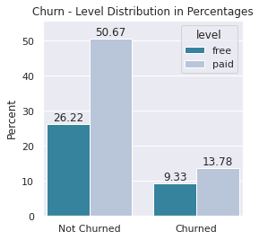

```python
# adjust figure size and font size
sns.set(rc = {"figure.figsize":(4,4)})
sns.set(font_scale=1)

# plot the churn distribution
ax = sns.barplot(x="churn", y="churn", data=df_panda,
                  estimator=lambda x: len(x) / len(df_panda) * 100, hue='level',
                  palette='PuBuGn_r')

# pad margins so that markers don't get clipped by the axes
plt.margins(x=0.02, y=0.1, tight=True);

# create labels and ticks
for container in ax.containers:
    ax.bar_label(container,  fmt='%.2f')
ax.set(xticklabels =["Not Churned", "Churned"])
plt.xlabel("")
plt.ylabel("Percent")

# restyle legend
labels = ['free', 'paid']
h, l = ax.get_legend_handles_labels()
ax.legend(h, labels, title="level")

# create title
plt.title("Churn - Level Distribution in Percentages");
```

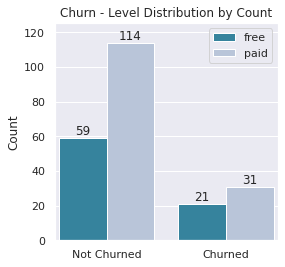

```python
# adjust figure size and font size
sns.set(rc = {"figure.figsize":(4,4)})
sns.set(font_scale=1)

# plot the churn distribution
ax = sns.countplot(x="churn", data=df_panda, hue="level",
                  palette='PuBuGn_r')

# pad margins so that markers don't get clipped by the axes
plt.margins(x=0.02, y=0.1, tight=True);

# create labels and ticks
for container in ax.containers:
    ax.bar_label(container)
ax.set(xticklabels =["Not Churned", "Churned"])
ax.legend(labels=["free", "paid"])
plt.xlabel("")
plt.ylabel("Count")

# create title
plt.title("Churn - Level Distribution by Count");
```

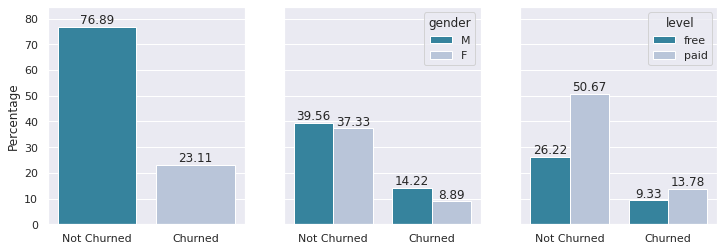

```python
# combine all graphs together for use in the report

# adjust figure size and font size
sns.set(rc = {"figure.figsize":(12,4)})
sns.set(font_scale=1)
f, axes = plt.subplots(1, 3, sharey=True)

# pad margins so that markers don't get clipped by the axes
plt.margins(x=2, y=0.1, tight=True);

# plot the churn distribution
ax = sns.barplot(x='churn', y='churn', data=df_panda,
                 estimator=lambda x: len(x) / len(df_panda) * 100,
                 palette='PuBuGn_r',
                 ax=axes[0])
# create labels and ticks
for container in ax.containers:
    ax.bar_label(container, fmt='%.2f')
ax.set(xticklabels =["Not Churned", "Churned"])
ax.set(xlabel="")
ax.set(ylabel="Percentage")


# plot the churn distribution with respect to gender
ax = sns.barplot(x='churn', y='churn', data=df_panda,
                 estimator=lambda x: len(x) / len(df_panda) * 100, hue='gender',
                 palette='PuBuGn_r',
                 ax=axes[1])
# create labels and ticks
for container in ax.containers:
    ax.bar_label(container, fmt='%.2f')
ax.set(xticklabels =["Not Churned", "Churned"])
ax.set(xlabel="")
ax.set(ylabel="")
# restyle the legend
labels = ['M', 'F']
h, l = ax.get_legend_handles_labels()
ax.legend(h, labels, title="gender")

# plot the churn distribution with respect to level
ax = sns.barplot(x="churn", y="churn", data=df_panda,
                  estimator=lambda x: len(x) / len(df_panda) * 100, hue='level',
                  palette='PuBuGn_r',
                  ax=axes[2])
# create labels and ticks
for container in ax.containers:
    ax.bar_label(container,  fmt='%.2f')
ax.set(xticklabels =["Not Churned", "Churned"])
ax.set(xlabel="")
ax.set(ylabel="")
# restyle the legend
labels = ['free', 'paid']
h, l = ax.get_legend_handles_labels()
ax.legend(h, labels, title="level");
```

### Songs per Session for Churn and Not Churned

```python
# display statistics for songs played per session
df_feats_cached.describe("songs_per_session").show()
```

```
+-------+-----------------+
|summary|songs_per_session|
+-------+-----------------+
|  count|              225|
|   mean| 69.0023306588992|
| stddev|42.32095423081715|
|    min|              3.0|
|    max|286.6666666666667|
+-------+-----------------+
```

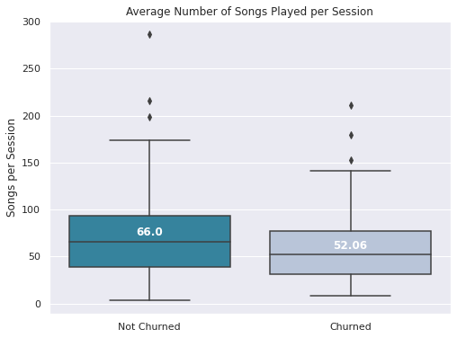

```python
# adding labels to medians from:
# https://pretagteam.com/question/labeling-boxplot-in-seaborn-with-median-value

# adjust figure size and font size
sns.set(rc = {"figure.figsize":(8,6)})
sns.set(font_scale=1)

# plot two boxplots
ax = sns.boxplot(x='churn', y = 'songs_per_session',
                 data = df_panda,
                 palette='PuBuGn_r')

# label the median lines
medians = round(df_panda.groupby(['churn'])['songs_per_session'].median(), 2)
vertical_offset = df_panda['songs_per_session'].median() * 0.1 # offset from median

for xtick in ax.get_xticks():
    ax.text(xtick, medians[xtick] + vertical_offset, medians[xtick],
      horizontalalignment = "center", color = "w", weight = "bold")

# create title and labels
plt.title('Average Number of Songs Played per Session')
ax.set(xticklabels=['Not Churned', 'Churned'])
ax.set_xlabel("")
ax.set_ylabel("Songs per Session");
```

### Actions per Session for Churn and Not Churned

```python
# display statistics for actions played per session
df_feats_cached.describe("acts_per_session").show()
```

```
+-------+------------------+
|summary|  acts_per_session|
+-------+------------------+
|  count|               225|
|   mean|31.053040008799456|
| stddev|32.154811754538564|
|    min|3.6315789473684212|
|    max|             259.0|
+-------+------------------+
```

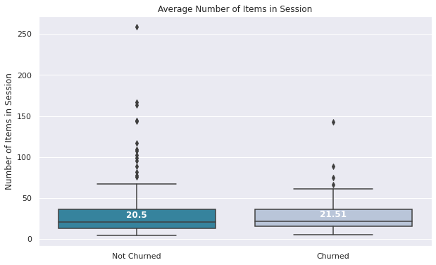

```python
# adjust figure size and font size
sns.set(rc = {"figure.figsize":(10,6)})
sns.set(font_scale=1)

# plot two boxplots
ax = sns.boxplot(x='churn', y = 'acts_per_session',
                 data = df_panda,
                 palette='PuBuGn_r')

# label the median lines
medians = round(df_panda.groupby(['churn'])['acts_per_session'].median(), 2)
vertical_offset = df_panda['acts_per_session'].median() * 0.25 # offset from median

for xtick in ax.get_xticks():
    ax.text(xtick, medians[xtick] + vertical_offset, medians[xtick],
      horizontalalignment = "center", color = "w", weight = "bold")

# create title and labels
plt.title('Average Number of Items in Session')
ax.set(xticklabels=['Not Churned', 'Churned'])
ax.set_xlabel("")
ax.set_ylabel("Number of Items in Session")
```

```
No artists with labels found to put in legend.  Note that artists whose label start with an underscore are ignored when legend() is called with no argument.
No artists with labels found to put in legend.  Note that artists whose label start with an underscore are ignored when legend() is called with no argument.
```

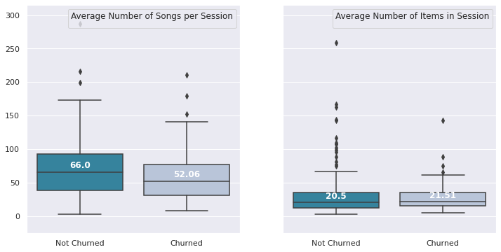

```python
# combine the above two boxplots in one figure for use in the report

# adjust figure size and font size
sns.set(rc = {"figure.figsize":(12,6)})
sns.set(font_scale=1)
f, axes = plt.subplots(1, 2, sharey=True)

# pad margins so that markers don't get clipped by the axes
plt.margins(x=2, y=0.1, tight=True);


# plot left side boxplots
ax = sns.boxplot(x='churn', y = 'songs_per_session',
                 data = df_panda,
                 palette='PuBuGn_r',
                 ax=axes[0])

# label the median lines
medians = round(df_panda.groupby(['churn'])['songs_per_session'].median(), 2)
vertical_offset = df_panda['songs_per_session'].median() * 0.1 # offset from median

for xtick in ax.get_xticks():
    ax.text(xtick, medians[xtick] + vertical_offset, medians[xtick],
      horizontalalignment = "center", color = "w", weight = "bold")

# create title and labels
plt.title('')
ax.set(xticklabels=['Not Churned', 'Churned'])
ax.set_xlabel("")
ax.set_ylabel("");
ax.legend(title="Average Number of Songs per Session");

# plot right side boxplots
ax = sns.boxplot(x='churn', y = 'acts_per_session',
                 data = df_panda,
                 palette='PuBuGn_r',
                 ax=axes[1])

# label the median lines
medians = round(df_panda.groupby(['churn'])['acts_per_session'].median(), 2)
vertical_offset = df_panda['acts_per_session'].median() * 0.25 # offset from median

for xtick in ax.get_xticks():
    ax.text(xtick, medians[xtick] + vertical_offset, medians[xtick],
      horizontalalignment = "center", color = "w", weight = "bold")

# create title and lfeabels
plt.title('')
ax.set(xticklabels=['Not Churned', 'Churned'])
ax.set_xlabel("")
ax.set_ylabel("");
ax.legend(title="Average Number of Items in Session");
```

### Received Ads per Session for Churn and Not Churned

```python
# display statistics for average number of ads received per session
df_feats_cached.describe("ads_per_session").show()
```

```
+-------+------------------+
|summary|   ads_per_session|
+-------+------------------+
|  count|               225|
|   mean|1.6459133170325297|
| stddev|1.7879873057253297|
|    min|               0.0|
|    max|              14.0|
+-------+------------------+
```

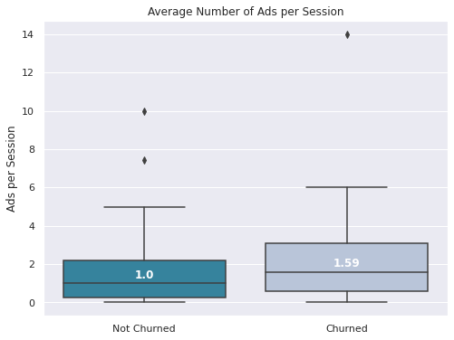

```python
# adjust figure size and font size
sns.set(rc = {"figure.figsize":(8,6)})
sns.set(font_scale=1)

# plot two boxplots
ax = sns.boxplot(x='churn', y = 'ads_per_session',
                 data = df_panda,
                 palette='PuBuGn_r')

# label the median lines
medians = round(df_panda.groupby(['churn'])['ads_per_session'].median(), 2)
vertical_offset = df_panda['ads_per_session'].median() * 0.25 # offset from median

for xtick in ax.get_xticks():
    ax.text(xtick, medians[xtick] + vertical_offset, medians[xtick],
      horizontalalignment = "center", color = "w", weight = "bold")

# create title and labels
plt.title('Average Number of Ads per Session')
ax.set(xticklabels=['Not Churned', 'Churned'])
ax.set_xlabel("")
ax.set_ylabel("Ads per Session");
```

### Likes, Dislikes, Upgrades and Downgrades vs. Churn

```python
# statistics for the four features
df_feats_cached.describe(["nr_likes", "nr_dislikes", "nr_upgrades", "nr_downgrades"]).show()
```

```
+-------+------------------+------------------+------------------+------------------+
|summary|          nr_likes|       nr_dislikes|       nr_upgrades|     nr_downgrades|
+-------+------------------+------------------+------------------+------------------+
|  count|               225|               225|               225|               225|
|   mean|55.782222222222224|11.315555555555555|2.2177777777777776| 9.133333333333333|
| stddev| 65.47792460907043|13.077481251105503|2.5585369082956606|11.734412152785014|
|    min|                 0|                 0|                 0|                 0|
|    max|               437|                75|                15|                73|
+-------+------------------+------------------+------------------+------------------+
```

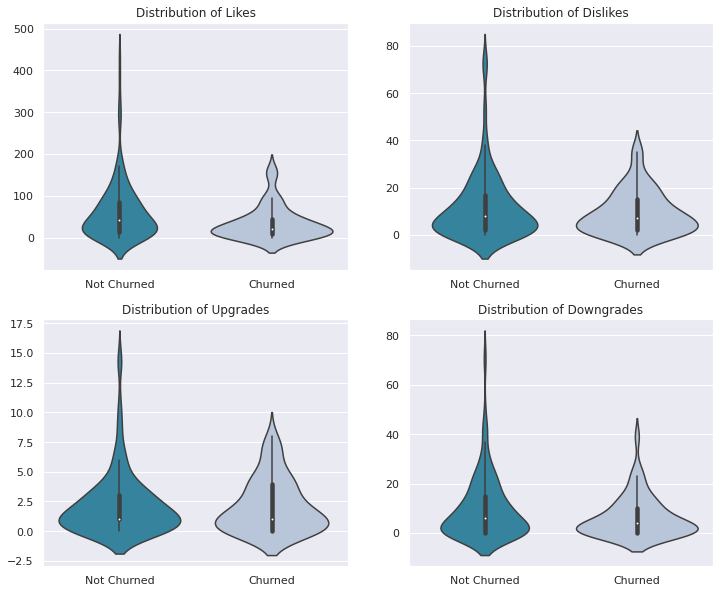

```python
# adjust figure size and font size
sns.set(rc = {"figure.figsize":(12,10)})
sns.set(font_scale=1)

# tick labels for x-axis
xticklabels = ['Not Churned', 'Churned'];

# plot on first row on left
plt.subplot(2,2,1)
ax1=sns.violinplot(data=df_panda, x="churn", y="nr_likes",
                   palette='PuBuGn_r');

plt.title("Distribution of Likes");
plt.xlabel("")
plt.ylabel("");
ax1.set_xticks([0, 1])
ax1.set_xticklabels(xticklabels);

# plot on first row on right
plt.subplot(2,2,2)
ax2=sns.violinplot(data=df_panda, x="churn", y="nr_dislikes",
                   palette='PuBuGn_r');

plt.title("Distribution of Dislikes");
plt.xlabel("")
plt.ylabel("");
ax2.set_xticks([0, 1])
ax2.set_xticklabels(xticklabels);

# plot on second row on left
plt.subplot(2,2,3)
ax3=sns.violinplot(data=df_panda, x='churn', y='nr_upgrades',
                   palette='PuBuGn_r');

plt.title("Distribution of Upgrades");
plt.xlabel("")
plt.ylabel("");
ax3.set_xticks([0, 1])
ax3.set_xticklabels(xticklabels);

# plot on second row on right
plt.subplot(2,2,4)
ax4=sns.violinplot(data=df_panda, x="churn", y='nr_downgrades',
                   palette='PuBuGn_r');

plt.title("Distribution of Downgrades");
plt.xlabel("")
plt.ylabel("");
ax4.set_xticks([0, 1])
ax4.set_xticklabels(xticklabels);
```

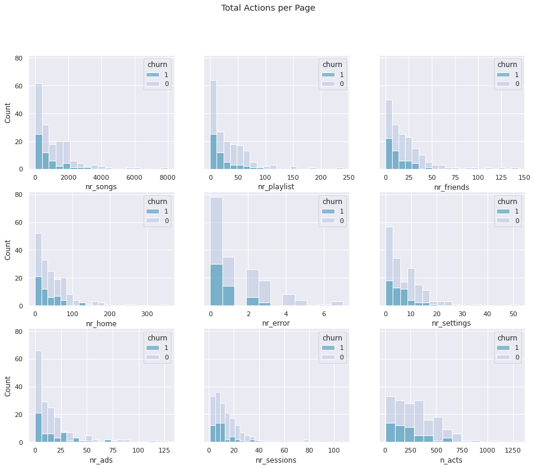

```python
# adjust figure size and font size
sns.set(rc = {"figure.figsize":(16,14)})
sns.set(font_scale=1)

# choose the individual plots figure properties
ncols = 3
nrows = 3
figsize = (ncols * 5, nrows * 4)

# assign fig and axes
fig, axes = plt.subplots(nrows=nrows, ncols=ncols, figsize=figsize, sharey=True)
fig.suptitle("Total Actions per Page")

# data as pandas dataframe with selected columns
cols_to_plot = ["churn", "nr_songs", "nr_playlist",
                "nr_friends", "nr_home", "nr_error",
                "nr_settings","nr_ads", "nr_sessions", "n_acts"]
data = df_panda[cols_to_plot]

# list of columns to plot
ylabels = cols_to_plot[1:]

# create a loop to plot each column
for i, y in enumerate(ylabels):
    sns.histplot(ax=axes[divmod(i, ncols)], data=data, x=y, hue="churn",
                 hue_order=[1,0],  palette='PuBuGn_r')
```

### Tenure days, active days and initial days intervals vs. Churn

```
No artists with labels found to put in legend.  Note that artists whose label start with an underscore are ignored when legend() is called with no argument.
No artists with labels found to put in legend.  Note that artists whose label start with an underscore are ignored when legend() is called with no argument.
No artists with labels found to put in legend.  Note that artists whose label start with an underscore are ignored when legend() is called with no argument.
```

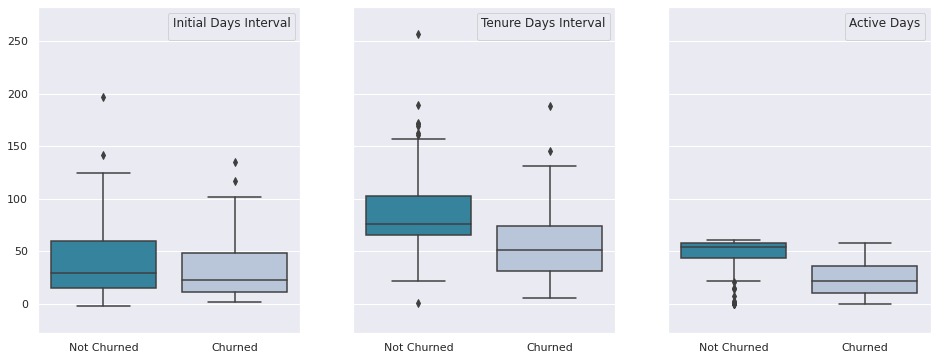

```python
# combine the plots in one figure for use in the report

# adjust figure size and font size
sns.set(rc = {"figure.figsize":(16,6)})
sns.set(font_scale=1)
f, axes = plt.subplots(1, 3, sharey=True)

# pad margins so that markers don't get clipped by the axes
plt.margins(x=2, y=0.1, tight=True);


# plot left side boxplots
ax = sns.boxplot(x='churn', y = 'init_days_interv',
                 data = df_panda,
                 palette='PuBuGn_r',
                 ax=axes[0])

# create title and labels
plt.title('')
ax.set(xticklabels=['Not Churned', 'Churned'])
ax.set_xlabel("")
ax.set_ylabel("");
ax.legend(title="Initial Days Interval");

# plot middle boxplots
ax = sns.boxplot(x='churn', y = 'tenure_days_interv',
                 data = df_panda,
                 palette='PuBuGn_r',
                 ax=axes[1])

# create title and labels
plt.title('')
ax.set(xticklabels=['Not Churned', 'Churned'])
ax.set_xlabel("")
ax.set_ylabel("");
ax.legend(title="Tenure Days Interval");

# plot right side boxplots
ax = sns.boxplot(x='churn', y = 'active_days',
                 data = df_panda,
                 palette='PuBuGn_r',
                 ax=axes[2])

# create title and labels
plt.title('')
ax.set(xticklabels=['Not Churned', 'Churned'])
ax.set_xlabel("")
ax.set_ylabel("");
ax.legend(title="Active Days");
```

## Split the Data

The dataset is imbalanced, and in order to ensure that the train set and the test set contain the same percentages of each class we will use stratified split.

```python
# source: https://stackoverflow.com/questions/47637760/stratified-sampling-with-pyspark
SPLIT_VALS = [.7, .3]

# split the data into train and test sets

def split_data (df):

    """
    Split the dataset into training set and test set.
    Use a stratified sampling method.
    """
    #train_set, test_set = df.randomSplit(SPLIT_VALS,seed=1234)

    # split dataframes between 0s and 1s
    zeros = df_feats.filter(df_feats["churn"]==0)
    ones = df_feats.filter(df_feats["churn"]==1)

    # split datasets into training and testing
    train0, test0 = zeros.randomSplit(SPLIT_VALS, seed=1234)
    train1, test1 = ones.randomSplit(SPLIT_VALS, seed=1234)

    # stack datasets back together
    train_set = train0.union(train1)
    test_set = test0.union(test1)

    return train_set, test_set
```

```python
# split the data in training set and test set
train_set, test_set = split_data(df_feats_cached)
```

```python
# print the size of each subset
print("The train set has {} records and the test set has {} records.".format(train_set.count(), test_set.count()))
```

```
The train set has 167 records and the test set has 58 records.
```

### Toggle the memory

```python
# remove features dataset from memory
df_feats_cached.unpersist()
```

```
DataFrame[nr_songs: bigint, nr_playlist: bigint, nr_friends: bigint, nr_likes: bigint, nr_dislikes: bigint, nr_downgrades: bigint, nr_upgrades: bigint, nr_home: bigint, nr_settings: bigint, nr_error: bigint, nr_ads: bigint, nr_sessions: bigint, n_acts: bigint, avg_sess_h: double, acts_per_session: d…
```

```python
# add the train set to the memory
train_cached = train_set.cache()
```

## Feature Relevance

### Normalized Median Difference Churn vs. Not Churn

```python
def median_diff(df, col, bincol):

    """
    Given the values in a column, computes the normalized difference between the medians
    of the subsets based on values in a categorical column.

    INPUT:
        df (Pandas dataframe) - dataframe that contains both columns
        col (Pandas series) - column in df, of integer, float type
        bincol (Pandas series) - column in df, with entries 0, 1
    OUTPUT:
        dictionary: key = nd_col, value = normalized_diff
    """
    median_one = abs(df[df[bincol]==1][col].median())
    median_zero = abs(df[df[bincol]==0][col].median())
    normalized_difference = (median_one - median_zero)/max(median_one, median_zero)
    return {"column": f"nd_{col}",
            "normal_diff": normalized_difference}
```

```python
# save the dataframe in pandas
train_panda = train_cached.toPandas()
# the numerical columns
num_cols = train_panda.columns[:20]

# create a Pandas dataframe with the normalized median differences
df_medians = pd.DataFrame(list(map(lambda col: median_diff(train_panda, col, "churn"), num_cols)))
df_medians = df_medians.sort_values(["normal_diff"], ascending = False).reset_index(drop = True)
df_medians
```

|  | column | normal_diff |
| --- | --- | --- |
| 0 | nd_ads_per_session | 0.339917 |
| 1 | nd_acts_per_session | 0.210256 |
| 2 | nd_nr_upgrades | 0.000000 |
| 3 | nd_nr_ads | -0.090909 |
| 4 | nd_nr_settings | -0.100000 |
| 5 | nd_nr_dislikes | -0.125000 |
| 6 | nd_init_days_interv | -0.147155 |
| 7 | nd_songs_per_session | -0.179907 |
| 8 | nd_nr_sessions | -0.181818 |
| 9 | nd_avg_sess_h | -0.232387 |
| 10 | nd_n_acts | -0.263941 |
| 11 | nd_nr_home | -0.264706 |
| 12 | nd_nr_friends | -0.312500 |
| 13 | nd_nr_songs | -0.332873 |
| 14 | nd_nr_downgrades | -0.333333 |
| 15 | nd_tenure_days_interv | -0.345032 |
| 16 | nd_nr_playlist | -0.425000 |
| 17 | nd_nr_likes | -0.500000 |
| 18 | nd_active_days | -0.600469 |
| 19 | nd_nr_error | -1.000000 |

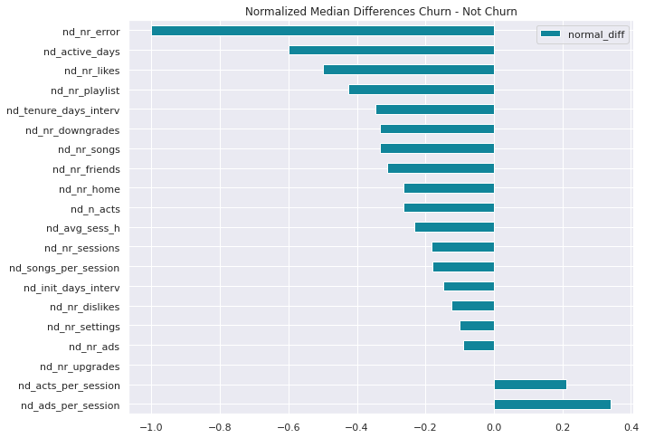

```python
# adjust figure size and font size
sns.set(rc = {"figure.figsize":(10, 8)})
sns.set(font_scale=1)

ax = df_medians.plot.barh(x='column', y='normal_diff',
                         color=colors[1], rot=0)

# create title and labels
plt.title("Normalized Median Differences Churn - Not Churn")
ax.set_xlabel("");
ax.set_ylabel("");
```

The normalized number of upgrades is pretty much the same for both groups of users, this indicates that the feature "nr_upgrades" does not add too much value to our models, at least for the small dataset. The larger the normalized median difference is, the more the feature varies between the "churn" and the "not churn" groups.

### Using Kendall rank correlation coefficient

From the Kendall rank correlation coefficient we get the following information:

several pairs of features are highly correlated

some features have small correlation ranks with the churn variable

However, we must keep in mind that this conclusion is based on the mini data, and we have to check what happens with in the full data set case.

```python
# create a pandas dataframe from the train set
train_panda = train_cached.toPandas()
```

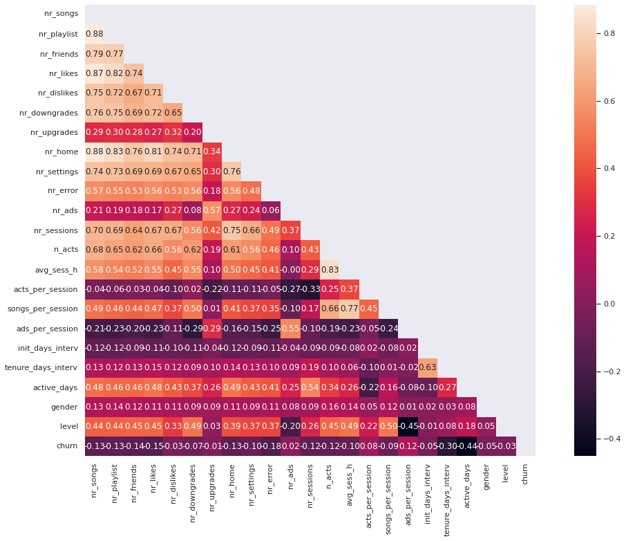

```python
# adjust figure size and font size
sns.set(rc = {"figure.figsize":(20, 12)})
sns.set(font_scale=1)

# compute the correlation matrix using
corr = train_panda.corr(method='kendall')

mask = np.zeros_like(corr)
mask[np.triu_indices_from(mask)] = True

sns.heatmap(corr,annot=True, fmt='.2f', square=True, mask = mask);
```

```python
# source:
#https://stackoverflow.com/questions/26463714/pandas-get-combination-of-columns-where-correlation-is-high

# find pairs of features with Kendall rank > 0.8
features = np.where(corr > 0.8)
features = [(corr.index[x], corr.columns[y]) for x, y in zip(*features)
                                        if x != y and x < y]
features
```

```
[('nr_songs', 'nr_playlist'),
 ('nr_songs', 'nr_likes'),
 ('nr_songs', 'nr_home'),
 ('nr_playlist', 'nr_likes'),
 ('nr_playlist', 'nr_home'),
 ('nr_likes', 'nr_home'),
 ('n_acts', 'avg_sess_h')]
```

```python
# the correlation indices with respect to "churn"
corr_indices = pd.DataFrame(corr["churn"].sort_values(ascending=False))
corr_indices = corr_indices.reset_index().rename({'index':'features', 'churn': 'kendall_corr'}, axis = 'columns')
corr_indices = corr_indices.iloc[1: , :]
corr_indices
```

|  | features | kendall_corr |
| --- | --- | --- |
| 1 | ads_per_session | 0.123456 |
| 2 | acts_per_session | 0.079519 |
| 3 | nr_ads | 0.016716 |
| 4 | nr_upgrades | -0.014914 |
| 5 | level | -0.026347 |
| 6 | nr_dislikes | -0.031803 |
| 7 | init_days_interv | -0.047907 |
| 8 | gender | -0.048708 |
| 9 | nr_downgrades | -0.074428 |
| 10 | songs_per_session | -0.085091 |
| 11 | nr_settings | -0.096298 |
| 12 | avg_sess_h | -0.104156 |
| 13 | n_acts | -0.117217 |
| 14 | nr_sessions | -0.121412 |
| 15 | nr_home | -0.126905 |
| 16 | nr_playlist | -0.127092 |
| 17 | nr_songs | -0.129228 |
| 18 | nr_friends | -0.136623 |
| 19 | nr_likes | -0.154348 |
| 20 | nr_error | -0.175994 |
| 21 | tenure_days_interv | -0.300311 |
| 22 | active_days | -0.435928 |

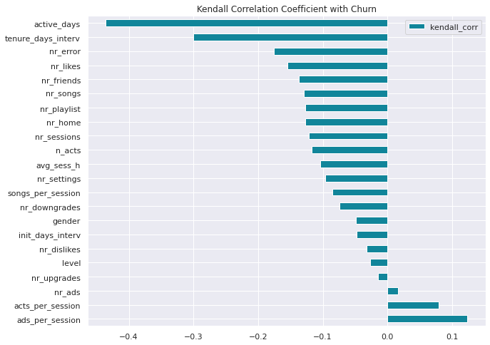

```python
# adjust figure size and font size
sns.set(rc = {"figure.figsize":(10, 8)})
sns.set(font_scale=1)

ax = corr_indices.plot.barh(x='features', y='kendall_corr',
                         color=colors[1], rot=0)

# create title and labels
plt.title("Kendall Correlation Coefficient with Churn")
ax.set_xlabel("");
ax.set_ylabel("");
```

```python
# find features with correlation rank with churn label closer to 0
ranks = corr_indices[(corr_indices.kendall_corr < 0.04) & (corr_indices.kendall_corr > - 0.04)]
ranks
```

|  | features | kendall_corr |
| --- | --- | --- |
| 3 | nr_ads | 0.016716 |
| 4 | nr_upgrades | -0.014914 |
| 5 | level | -0.026347 |
| 6 | nr_dislikes | -0.031803 |

We notice that "nr_ads" and "nr_upgrades" have the weakest correlations with churn.

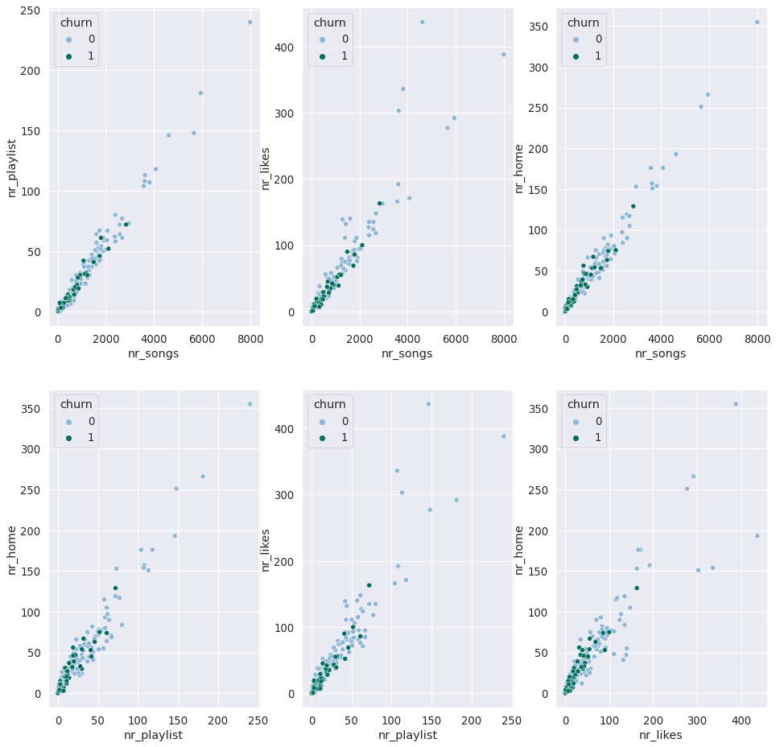

```python
# adjust figure size and font size
sns.set(rc = {"figure.figsize":(16, 16)})
sns.set(font_scale=1.2)

plt.subplot(2,3,1)
sns.scatterplot(x='nr_songs',y='nr_playlist',hue='churn',data=train_panda,
               palette = [colors[3], colors[0]])
plt.subplot(2,3,2)
sns.scatterplot(x='nr_songs',y='nr_likes',hue='churn',data=train_panda,
               palette = [colors[3], colors[0]])
plt.subplot(2,3,3)
sns.scatterplot(x='nr_songs',y='nr_home',hue='churn',data=train_panda,
             palette = [colors[3], colors[0]]);

plt.subplot(2,3,4)
sns.scatterplot(x='nr_playlist',y='nr_home',hue='churn',data=train_panda,
               palette = [colors[3], colors[0]])
plt.subplot(2,3,5)
sns.scatterplot(x='nr_playlist',y='nr_likes',hue='churn',data=train_panda,
               palette = [colors[3], colors[0]])
plt.subplot(2,3,6)
sns.scatterplot(x='nr_likes',y='nr_home',hue='churn',data=train_panda,
             palette = [colors[3], colors[0]]);
```

We can remove three of the above features, keep only "nr_likes". This is relevant for the mini dataset.

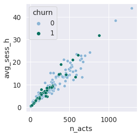

```python
# adjust figure size and font size
sns.set(rc = {"figure.figsize":(4, 4)})
sns.set(font_scale=1.2)

sns.scatterplot(x='n_acts',y='avg_sess_h',hue='churn',data=train_panda,
               palette = [colors[3], colors[0]]);
```

The following features could be removed:

nr_ads, nr_upgrades - due to weak correlation with churn,

nr_playlist, nr_home, nr_songs - due to high correlation among each other and with nr_likes.

### Toggle the memory

```python
# remove features dataset from memory
train_cached.unpersist()
```

```
DataFrame[nr_songs: bigint, nr_playlist: bigint, nr_friends: bigint, nr_likes: bigint, nr_dislikes: bigint, nr_downgrades: bigint, nr_upgrades: bigint, nr_home: bigint, nr_settings: bigint, nr_error: bigint, nr_ads: bigint, nr_sessions: bigint, n_acts: bigint, avg_sess_h: double, acts_per_session: d…
```

## Remove features and save data for modeling

```python
# columns to drop
drop_cols = ("nr_ads", "nr_upgrades",
             "nr_playlist", "nr_home", "nr_songs")

# drop columns from the train set
train_set_reduced = train_set.drop(*drop_cols)

# drop columns from the test set
test_set_reduced = test_set.drop(*drop_cols)
```

```python
# save train set as json file
path_trainset = "data/mini_sparkify_train_data.json"

# save the train data to a file
save_data(train_set_reduced, path_trainset)
```

```python
# save test set as json file
path_testset = "data/mini_sparkify_test_data.json"

# save the test data to a file
save_data(test_set_reduced, path_testset)
```

```python
# upload the train data
df_train = load_data(path_trainset)
df_train.show(1, vertical=True)
```

```
Loading the dataset ...
Dataset is loaded...
-RECORD 0--------------------------------
 active_days        | 43.06047453703704
 acts_per_session   | 8.777777777777779
 ads_per_session    | 1.6666666666666667
 avg_sess_h         | 3.050209163346616
 churn              | 0
 gender             | 0
 init_days_interv   | 88.62469907407407
 level              | 0
 n_acts             | 79
 nr_dislikes        | 2
 nr_downgrades      | 0
 nr_error           | 0
 nr_friends         | 0
 nr_likes           | 10
 nr_sessions        | 9
 nr_settings        | 3
 songs_per_session  | 22.444444444444443
 tenure_days_interv | 131.6851736111111
only showing top 1 row
```

```python
# upload the test data
df_test = load_data(path_testset)
df_test.show(1, vertical=True)
```

```
Loading the dataset ...
Dataset is loaded...
-RECORD 0--------------------------------
 active_days        | 44.21780092592593
 acts_per_session   | 16.0
 ads_per_session    | 7.428571428571429
 avg_sess_h         | 3.389725138524355
 churn              | 0
 gender             | 1
 init_days_interv   | 11.425856481481482
 level              | 0
 n_acts             | 112
 nr_dislikes        | 5
 nr_downgrades      | 0
 nr_error           | 0
 nr_friends         | 4
 nr_likes           | 17
 nr_sessions        | 7
 nr_settings        | 0
 songs_per_session  | 39.285714285714285
 tenure_days_interv | 55.64365740740741
only showing top 1 row
```